# Airline Data Analysis

Pirogova Anna

## Task

Based on the data (and the questions given), try to find out:

- What are the problems in air travel?
- What improvements can be suggested based on the findings from the data?

#### Data Loading and Conversion

The following data transformations were made:

1. The names of aircraft models in the seat table in the aircraft column were brought to a single form so that the values for each of the models were calculated correctly (replacing capital letters with capital letters, replacing A with Airbus, B with Boeing).
2. The - signs were removed from the airport_name column in the airport_rating table (created based on the original airport table) and brought to the form “Airport Name”
3. The words REVIEW and CUSTOMER at the end of the name of the lounge areas have been removed (lounge_name column in the lounge_rating table, created based on the original lounge table).It was also decided to include (in parentheses) the name of the corresponding airport in the names of the lounge areas, because from the names of some lounge areas it is impossible to identify which airline and airport they belong to
4. The “airport_name” column has been renamed to “airport” so that the join function correctly joins tables by lounge areas and airports
5. To answer the third question, the NA values in the wifi_connectivity_rating column in the airport table were omitted

### Questions

#### Question 1

**Question:**Which aircraft have the most comfortable legroom?

**Data:**to answer the question you need seat tables

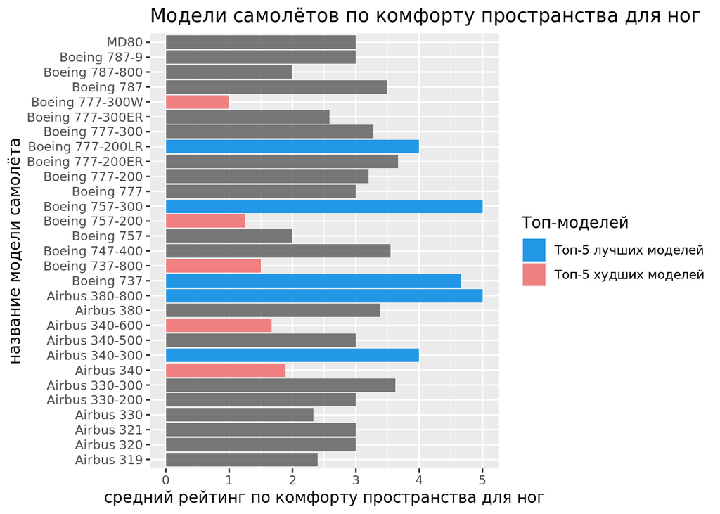

**Answer:**The top 5 best aircraft models for legroom comfort include Airbus 340-300, Airbus 380-800 Boeing 737, Boeing 757-300, Boeing 777-200LR.While the top 5 worst include Boeing 777-300W, Boeing 757-200 Boeing 737-800, Airbus 340-600, Airbus 340.

**Conclusion:**The analysis did not include ratings from customers who used the same questionnaire for multiple models because the average rating of multiple different models is biased at the specific model level.Recommendations: Maintain legroom quality at least at the same level for top models, be sure to improve legroom for aircraft with a rating of 2 or less.Recommendation for changing the questionnaire: propose to evaluate each aircraft model separately in order to avoid situations where it is unclear which model the assessment relates to.It is also recommended to introduce a uniform model name standard (eg, “Boeing 757-300”) Plans for further research: Determine whether there is a correlation between legroom comfort ratings and overall seating ratings.

#### Question 2

**Question:**How many routes with transfers are in our database?

**Data:**To answer the question you need airline tables

| Flight type | Number of flights |
| --- | --- |
| direct flights | 906 |
| flights with transfers | 94 |

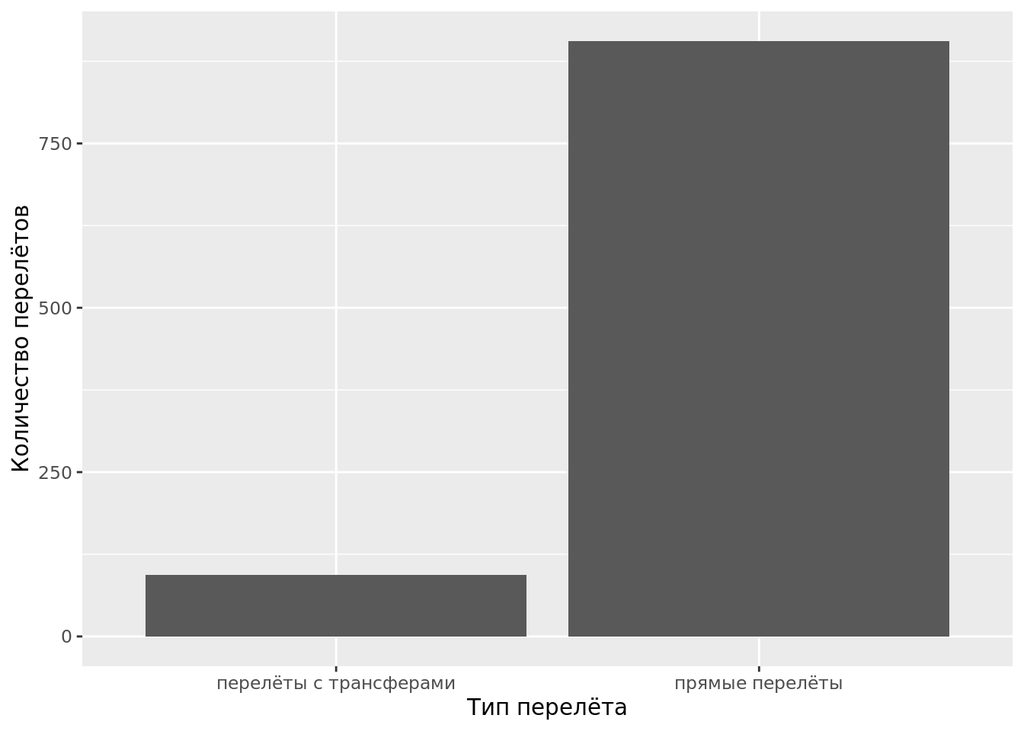

**Answer:**Our database contains 94 routes with transfers

**Conclusion:**Since there is virtually no transfer information in the directions column, we had to use the customer review suppression column to determine whether the route included transfers.Therefore, to more accurately answer the question, it is recommended to collect more data.For example, make a separate mandatory question in the questionnaire “Did your route have transfers”, where you will need to select “Yes” or “No”.

#### Question 3

**Question:**Which lounge areas are rated higher in wi-fi quality than the airports in which they are located?

**Data:**To answer the question you need the tables airport,lounge

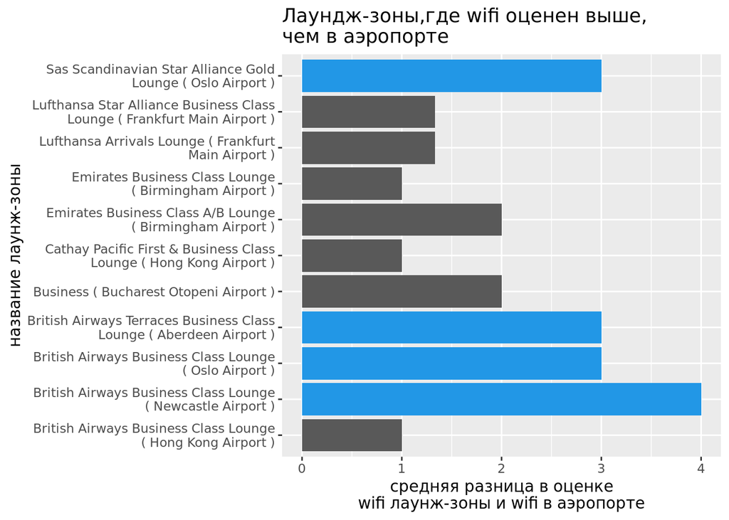

**Answer:**11 lounge areas are rated higher in Wi-Fi quality than the airports in which they are located.Their names are on the graph above.

### Dashboard

The findings are summarized in the form of a dashboard with the following elements

#### **Element 2:**

- view: table
- answer to question: 2
- justification: In this case, the table shows the number of flights with and without transfers.The graph in this case would not be indicative, since a lot of data is missing.

#### **Element 3:**

- type: chart
- answer to question: 3
- Rationale: In this case, the graph best answers the question because it allows you to show not only the names of the lounge areas, but also the average difference in the wifi rating in the lounge compared to the wifi rating at the corresponding airport.4 lounge areas in which the difference in wifi ratings is the greatest are highlighted in blue.At these airports, it is necessary to check why the quality of wifi is reduced in the airports themselves, although it is at a higher level in the lounge areas.

### General conclusions

#### **Recommendations for the questionnaire and collecting scores**

It is recommended to change the questionnaire:

- add a mandatory question about the presence/absence of transfers
- introduce a unified standard for naming aircraft models
- it is additionally recommended to reduce the number of questions in the questionnaire by removing unimportant ones
- make it mandatory to ask about the quality of wifi connection at the airport

For example, you can remove questions about termial_signs_rating because there is almost no data on them, and therefore the conclusions are inaccurate and questionable.At the same time, key assessment parameters should be placed at the beginning of the survey and response to them should be mandatory.All of the above will expand the possibilities of further research and simplify their implementation.